# act_report

## Analysis and Visualisation of Tweeter Data

> **Insights**:

> `Insight 1`: WHAT ARE THE TOP 5 MOST FREQUENT DOG BREEDS IN THIS TWEETER DATA?

> `Analysis`: To anwer this question and gain an insight, we had to identify the total count number for each breed in the data provided. The main challenge here was to clean out and identify the breed names from the images data, bringing all the breed names to a single format (Capitalized), getting rid of duplicates and sorting it to get the top 5 most frequent breeds.

> `Answer`: Golden Retriever - 158, Labrador Retriever - 108, Pembroke - 95, Chihuahua - 91 and Pug - 62

> **Insights**:

> `Insight 2`: WHAT ARE THE TOP 5 MOST FAVORITE DOG BREEDS IN THIS TWEETER DATA?

> `Analysis`: To answer this question and gain the second insight, we had to identify the breeds with the most number of favorite and retweet count. Building on the work used to get the first insight, the main tasks here were to add the columns witht the favorite and retweet count, and to sort them to get the top 5 most favorite breeds.

> `Answer`: Labrador Retriever - 210590, Lakeland Terrier - 181075, Chihuahua - 163640, English Springer - 153805, French Bulldog - 139710

> **Insights**:

> `Insight 3`: DID 5 MOST POPULAR DOGS FALL WITHIN THE 5 MOST FREQUENT BREEDS?

> `Analysis`: To answer this question and gain the third insight, we had to compare the 2 initial insights.

> `Answer`: Only Labrador Retriever and Chihuahua were found in both categories.

> **Visualisation**:

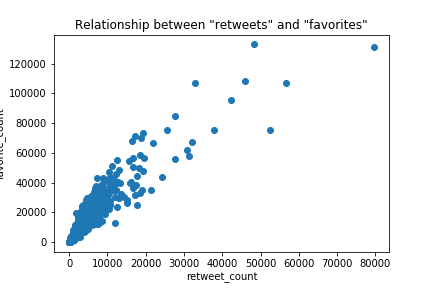

```python
from PIL import Image
%config InlineBackend.figure_format = 'retina'
img = Image.open("retweets.png")
img
```

> `Insight 4`: IS THERE A RELATIONSHIP BETWEEN RETWEET AND FAVOURITE COUNT?

> `Analysis`: To answer this question and gain the fourth insight, we used the scatter plot to investigate a possible relationship.

> `Answer`: The resulting plot clearly shows a positive relationship between the 'retweet_count' and 'favorite_count'. This means that a dog with a higher number of retweets is likely to have a higher number of favorites.